# final

Dongkeon Oh

2018년 9월 4일

```r
library(dplyr)
library(ggmap)
library(maps)
library(mapdata)
library(ggplot2)
library(broom)
library(knitr)
library(MASS)
Raw = read.csv('C:/Users/renz/Desktop/장성규 기말/Final/mobility.csv')
```

### 1. A map of mobility

#### a 회색조 지도. (미국 전역)

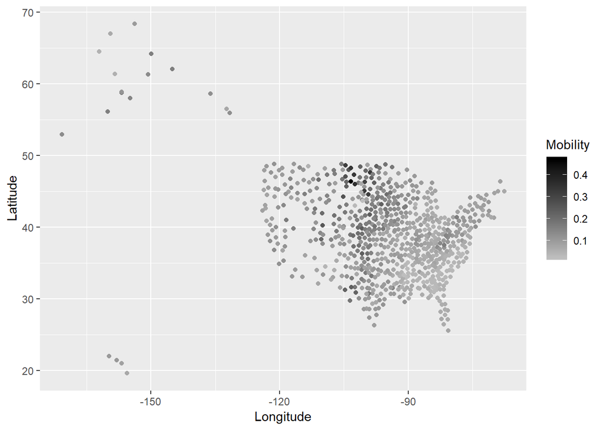

```r
ggplot(data = Raw, aes(x = Longitude, y = Latitude, col = Mobility)) +
  geom_point() +
  scale_color_gradient(low="grey", high="black")
```

mobility 가 높은 곳일 수록 진해진다.  
중부 지역이 다른 지역에 비해 상대적으로 mobility가 높아 보인다.

#### b 두 범주 지도. (미국 본토)

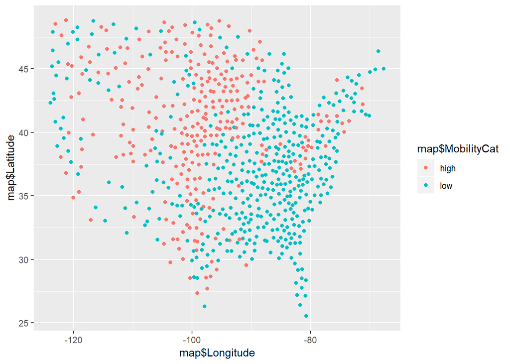

```r
map <- Raw %>% filter(!is.na(Raw$Mobility))
map$MobilityCat <- ifelse(map$Mobility > 0.1, "high","low")
map <- map %>% filter(Longitude > -145, Latitude < 50)
ggplot(data = map, aes(x = map$Longitude, y = map$Latitude, col = map$MobilityCat)) +
    geom_point()
```

중서부 지역과 동부 지역과 뚜렷한 대비가 보인다.  
그리고 서부 지역중에서도 도시가 발달한 연안은 mobility가 낮았다.  
a 지도에 비해 지역에 따른 mobility의 대비가 선명하게 나타난다.

### 2. A bunch of simple regression models

A bunch of simple regression models

| term | estimate | std.error | statistic | p.value |
| --- | --- | --- | --- | --- |
| Population | 0.0000000 | 0.0000000 | -3.6694570 | 0.0002608 |
| Income | 0.0000003 | 0.0000003 | 0.9114705 | 0.3623496 |
| Seg_racial | -0.1835019 | 0.0183933 | -9.9765780 | 0.0000000 |
| Share01 | -0.0017182 | 0.0003518 | -4.8835021 | 0.0000013 |
| School_spending | 0.0114643 | 0.0016623 | 6.8965693 | 0.0000000 |
| Violent_crime | -10.0505704 | 1.2943766 | -7.7647960 | 0.0000000 |
| Commute | 0.2218695 | 0.0112422 | 19.7353372 | 0.0000000 |

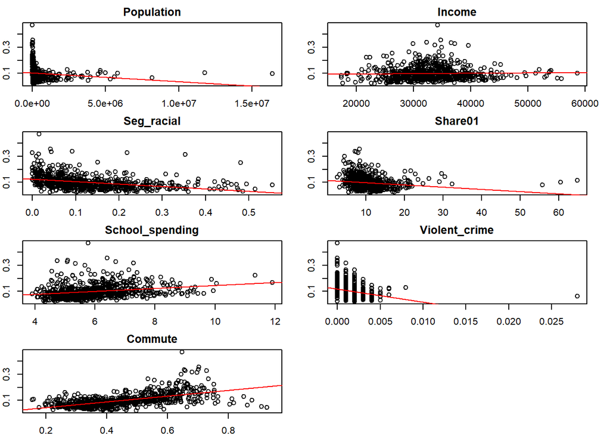

```r
par(mar = rep(2, 4))
par(mfrow = c(4,2))
index = c(5,13,8,15,22,38,12)
# 문제에서 제시된 항목만 단일회귀분석을 진행한다.
coef_table_simples = NULL
for (i in index){
  plot(Mobility~Raw[,i], main = names(Raw)[i], data = Raw)
  lm.fit = lm(Mobility~Raw[,i], data = Raw)
  abline(lm.fit, col = "red")
  temp = tidy(lm(Raw$Mobility~Raw[,i]))[2,]
  temp$term = names(Raw)[i]
  coef_table_simples = rbind(coef_table_simples,temp)

}

kable(coef_table_simples, caption = "A bunch of simple regression models")
```

#### 2-1 log변환이 필요한 변수: population

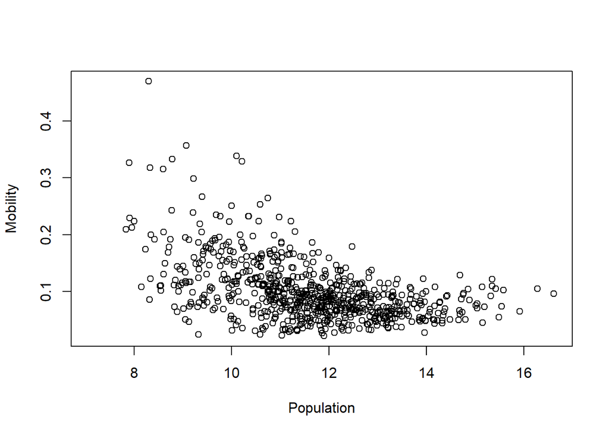

```r
Raw$Population <-log(Raw$Population)
plot(Mobility~Population, data = Raw)
```

#### 2-2 적합하지 않은 변수(높은 p-value 값): income

일반적으로 소득이 높으면 계층적 이동성이 높을 것이라고 생각하기 쉽다.  
그러나 단일회귀 결과 소득은 계층적 이동성을 설명하는데 유의미하지 않다.  
(그 이유는 무엇인가?)

### 3. All things considered

#### a. remove unappropriate variables : ID, 주이름, 동네이름, 위도, 경도

```r
Raw_use <- Raw[-c(1,2,4,42,43)]
lm_mul = lm(Mobility ~., data = Raw_use)
coef_table_multiple = tidy(lm_mul)
```

#### b ID를 빼야하는 이유.

ID 커뮤니티 식별코드는 어떠한 인과관계에 의한 것이 아니라 구분을 위해 “랜덤하게” 주어진 값이기 때문에 반응변수와 상관관계 없어야 한다.

#### c 그 외 변수를 뺀 이유.

동네 이름 또한 커뮤니티 식별코드 마찬가지 이유로 제거했다.  
미국의 주, 위도, 경도 또한 “그 자체”로는 지역적 구분의 의미만 있기 때문에 반응변수를 해석할 때 어려움이 있기 때문에 제거했다.  
(지역적 구분이 반응변수를 설명하는 적절한 변수가 될 수 있는가?)  
(예를 들어 평균기온과 위도)

#### d unappropriate variables를 제외한 경우와 그렇지 않은 경우의 회귀계수 비교.

```r
kable(coef_table_simples, caption = "coef table simple regressions")
```

coef table simple regressions

| term | estimate | std.error | statistic | p.value |
| --- | --- | --- | --- | --- |
| Population | 0.0000000 | 0.0000000 | -3.6694570 | 0.0002608 |
| Income | 0.0000003 | 0.0000003 | 0.9114705 | 0.3623496 |
| Seg_racial | -0.1835019 | 0.0183933 | -9.9765780 | 0.0000000 |
| Share01 | -0.0017182 | 0.0003518 | -4.8835021 | 0.0000013 |
| School_spending | 0.0114643 | 0.0016623 | 6.8965693 | 0.0000000 |
| Violent_crime | -10.0505704 | 1.2943766 | -7.7647960 | 0.0000000 |
| Commute | 0.2218695 | 0.0112422 | 19.7353372 | 0.0000000 |

```r
kable(coef_table_multiple [c(2,10,5,12,19,35,9),], caption = "coef table multiple regression")
```

coef table multiple regression

| term | estimate | std.error | statistic | p.value |
| --- | --- | --- | --- | --- |
| Population | -0.0035444 | 0.0027490 | -1.2893506 | 0.1980605 |
| Income | 0.0000007 | 0.0000006 | 1.1492352 | 0.2511818 |
| Seg_racial | -0.0367880 | 0.0166516 | -2.2092806 | 0.0277510 |
| Share01 | -0.0309320 | 0.0289773 | -1.0674592 | 0.2864422 |
| School_spending | 0.0003733 | 0.0019451 | 0.1919219 | 0.8479059 |
| Violent_crime | -3.6712249 | 1.4796624 | -2.4811233 | 0.0135287 |
| Commute | 0.0524024 | 0.0256245 | 2.0450095 | 0.0415423 |

#### d-2 유의확률이 유의미하게 높게 변한 변수: population, share01,School_spending

population, share01,School_spending 세 개의 변수는 단일회귀에서는 유의미했지만,  
다중회귀분석에서는 더이상 유의미하지 않다.  
(그 이유는 무엇인가?)

#### e 다중공선성 분석.

##### e-1 공선성이 있는 것으로 의심되는 변수를 확인.

```r
library(car)
vif(lm_mul)
```

```
##                Population                     Urban
##                  9.626912                  2.619839
##                     Black                Seg_racial
##                 10.153244                  2.133808
##                Seg_income               Seg_poverty
##                519.741537                128.970199
##             Seg_affluence                   Commute
##                159.335868                  7.966949
##                    Income                      Gini
##                  6.606759              41495.034086
##                   Share01                   Gini_99
##              11642.298376              22312.576251
##              Middle_class            Local_tax_rate
##                  8.942226                  2.519242
##        Local_gov_spending             Progressivity
##                  2.154500                  1.472788
##                      EITC           School_spending
##                  2.178677                  3.450567
##     Student_teacher_ratio               Test_scores
##                  2.096335                  3.496397
##                HS_dropout                  Colleges
##                  1.863280                  2.115890
##                   Tuition                Graduation
##                  1.824107                  2.160268
## Labor_force_participation             Manufacturing
##                  5.584794                  2.635309
##           Chinese_imports             Teenage_labor
##                  1.359915                  5.966240
##              Migration_in             Migration_out
##                  5.028361                  4.896258
##              Foreign_born            Social_capital
##                  2.807560                  6.129904
##                 Religious             Violent_crime
##                  2.043913                  1.778991
##            Single_mothers                  Divorced
##                 16.059384                  3.698898
##                   Married
##                  6.059057
```

```r
print(attr(vif(lm_mul),"names")[vif(lm_mul) > 10])
```

```
## [1] "Black"          "Seg_income"     "Seg_poverty"    "Seg_affluence"
## [5] "Gini"           "Share01"        "Gini_99"        "Single_mothers"
```

총 8개의 변수의 vif가 10을 넘는다. 이 변수들은 공산성이 의심된다.

##### e-2 산점도를 통해 어떤 변수가 공산성이 있는지를 특정.

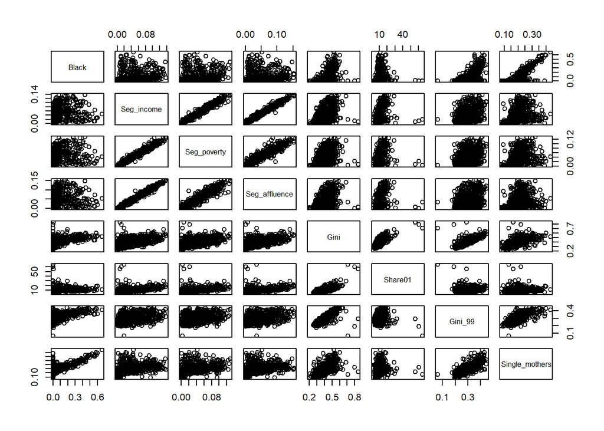

```r
index = vif(lm_mul) > 10
pairs(Raw_use[-1][,index])
```

첫번째로 seg_income과 seg_poverty, seg_affluence가 서로 선형관계가 있음을 확인할 수 이다. 모두 소득에 따른 지역분화의 정도를 나타내는 지표이기 때문에 서로 상관관계를 갖는 것이 타당하다. 따라서 세 변수를 평균을 내어 seg_wealth 라는 변수를 만들어 하나의 변수로 처리한다.  
두번째로 Gini가 share01와 Gini_99변수와 각각 선형관계가 있는 반면, share01과 Gini_99변수는 선형관계가 없다. 따라서 Gini변수를 제거한다.상위 1퍼센트에 부가 몰릴수록 지니계수가 높아지기 때문에 Gini와 share01이 상관관계를 갖는 것은 당연하다. 또한 지니계수가 높을 수록 소득 불평등이 크다는 의미이기 때문에 Gini_99 또한 Gini와 상관성을 갖는다. 다만, share01과 gini_99는 상관성이 낮은데, 이는 상위 1퍼센트의 부의 집중이 나머지 99퍼센트끼리의 소득불평등과 상관이 없다는 의미이다. 이는 한 집단 내에서 부의 분배가 언제나 역피라미드식으로 smooth하게 이루어지지는 않다는 점을 시사한다.  
(해석의 비약은 없는가?)  
마지막으로 single_mothers변수, Gini_99변수, Black 사이의 선형성이 확인된다.세가지 변수가 서로 상관성을 갖는 것은 명백하지만 세 변수가 의미하는 바가 다르기 때문에 segment처럼 단일 변수로 처리하기 어려움이 있다. 세 변수 중 한 변수를 제거해야한다. 어떤 변수를 선택해야할 지 잘 모르겠어서 vif를 가장 잘 개선하는 single_mother 변수를 제거했다.  
(세 변수 사이에서의 선택이 자의적인가?)  
(이혼율과 single_mother의 공선성이 나타나지 않는 이유?)

##### e-3 공산성 제거를 위한 변수 선택.

```r
attach(Raw)
sum(is.na(Seg_affluence))
```

```
## [1] 0
```

```r
sum(is.na(Seg_income))
```

```
## [1] 0
```

```r
sum(is.na(Seg_poverty))
```

```
## [1] 0
```

```r
Raw_use$Seg_wealth = (Seg_affluence+Seg_income+Seg_poverty)/3

Raw_unvif = subset(Raw_use, select = - c(Seg_affluence,Seg_income,Seg_poverty,Gini,Single_mothers))
lm_mul_unvif = lm(Mobility~., data = Raw_unvif)
vif(lm_mul_unvif)
```

```
##                Population                     Urban
##                  9.530559                  2.565386
##                     Black                Seg_racial
##                  6.017064                  1.935458
##                   Commute                    Income
##                  7.484916                  6.510777
##                   Share01                   Gini_99
##                  1.492723                  7.178872
##              Middle_class            Local_tax_rate
##                  8.250403                  2.487003
##        Local_gov_spending             Progressivity
##                  2.138449                  1.467751
##                      EITC           School_spending
##                  2.130982                  3.393464
##     Student_teacher_ratio               Test_scores
##                  2.084168                  3.397100
##                HS_dropout                  Colleges
##                  1.845034                  2.107081
##                   Tuition                Graduation
##                  1.803935                  1.955522
## Labor_force_participation             Manufacturing
##                  5.069204                  2.567620
##           Chinese_imports             Teenage_labor
##                  1.308934                  5.789285
##              Migration_in             Migration_out
##                  4.924463                  4.805376
##              Foreign_born            Social_capital
##                  2.659160                  5.827139
##                 Religious             Violent_crime
##                  2.011001                  1.755624
##                  Divorced                   Married
##                  2.737542                  3.921349
##                Seg_wealth
##                  6.026913
```

```r
detach(Raw)
```

변수 조정 결과, 모든 변수의 vif가 10미만으로 조정되었다.

### 4.Please in my front yard

#### a 결측치의 갯수 확인.

```r
attach(Raw)
sum(is.na(Colleges))
```

```
## [1] 157
```

```r
sum(is.na(Tuition))
```

```
## [1] 161
```

```r
sum(is.na(Graduation))
```

```
## [1] 160
```

```r
detach(Raw)
```

#### b 결측치의 무작위성 확인

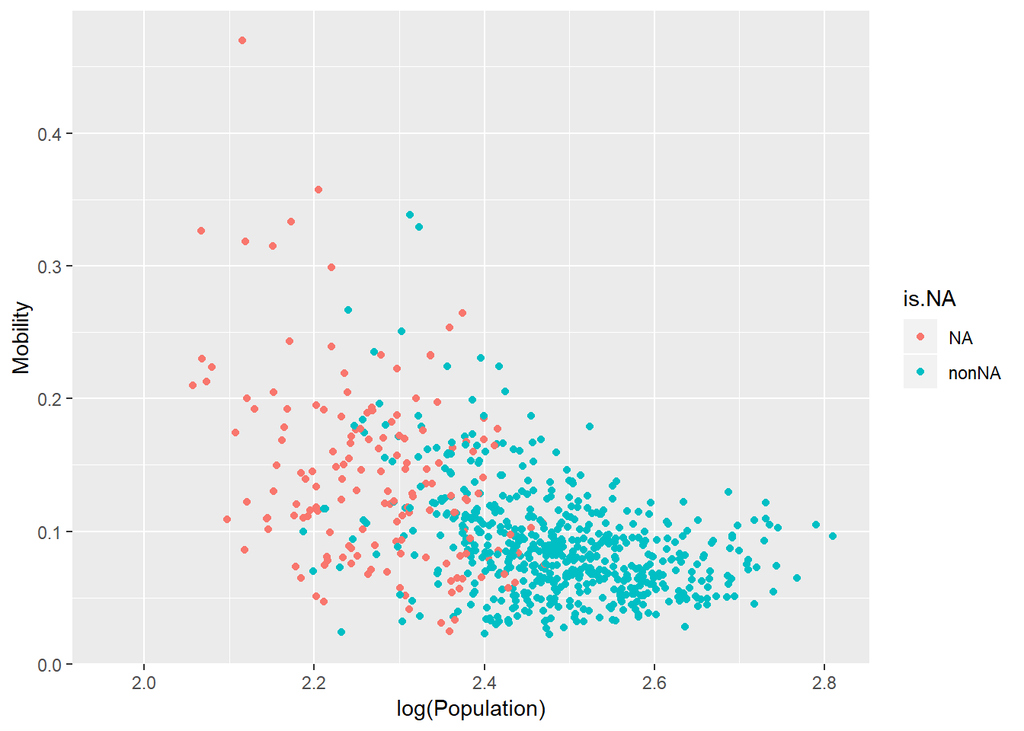

```r
map_na = Raw
attach(map_na)
map_na$is.NA <- ifelse(is.na(Colleges) | is.na(Tuition) | is.na(Graduation), "NA", "nonNA")
ggplot(data = map_na, aes(x = log(Population) ,y =Mobility, color = is.NA)) +
  geom_point()
```

```r
detach(map_na)
```

인구가 적은 지역은 결측치가 많은 경향이 있다.  
이는 대학과 같은 상위교육기관이 인구가 적은 집단에 있지 않고 인구가 많은 도시 지역에 몰려 있기 때문으로 추정된다.

#### c 새로운 범주형 변수 생성.

다른 집단에서 대학을 졸업했을 수도 있고, 등록금이 무상인 경우도 있을 수 있기 때문에  
1인당 대학수가 NA인 집단만 대학이 없는 곳으로 판단했다.

```r
Raw_unvif$HE <- ifelse(is.na(Raw_unvif$Colleges) == TRUE,FALSE,TRUE)
Raw_unvif$Colleges[is.na(Raw_unvif$Colleges)] <- 0
Raw_unvif$Tuition[is.na(Raw_unvif$Tuition)] <- 0
Raw_unvif$Graduation[is.na(Raw_unvif$Graduation)] <- 0
```

결측치 값을 0으로 바꾸고 HE 변수를 추가했다.

### 5. 새로운 다중회귀분석

```r
lm_mul_new = lm(Mobility~., data = Raw_unvif)
summary(lm_mul_new)
```

```
##
## Call:
## lm(formula = Mobility ~ ., data = Raw_unvif)
##
## Residuals:
##       Min        1Q    Median        3Q       Max
## -0.071849 -0.014837 -0.002191  0.011520  0.136154
##
## Coefficients:
##                             Estimate Std. Error t value Pr(>|t|)
## (Intercept)                2.015e-02  5.962e-02   0.338  0.73551
## Population                -5.156e-03  2.709e-03  -1.904  0.05754 .
## Urban                     -1.667e-03  3.970e-03  -0.420  0.67473
## Black                     -2.187e-02  2.085e-02  -1.049  0.29466
## Seg_racial                -7.317e-02  1.636e-02  -4.472 9.64e-06 ***
## Commute                    3.002e-03  2.526e-02   0.119  0.90544
## Income                     6.798e-07  5.493e-07   1.238  0.21647
## Share01                    6.797e-05  3.401e-04   0.200  0.84169
## Gini_99                   -9.231e-02  5.169e-02  -1.786  0.07474 .
## Middle_class               1.750e-01  3.941e-02   4.442 1.10e-05 ***
## Local_tax_rate             6.837e-01  2.135e-01   3.202  0.00145 **
## Local_gov_spending         8.736e-07  1.856e-06   0.471  0.63810
## Progressivity              8.069e-03  1.181e-03   6.834 2.44e-11 ***
## EITC                      -6.010e-04  4.180e-04  -1.438  0.15112
## School_spending           -5.217e-04  1.835e-03  -0.284  0.77634
## Student_teacher_ratio      2.507e-03  9.155e-04   2.738  0.00640 **
## Test_scores                1.207e-04  2.626e-04   0.460  0.64584
## HS_dropout                -2.268e-01  7.980e-02  -2.841  0.00468 **
## Colleges                  -5.277e-02  8.398e-02  -0.628  0.53004
## Tuition                    1.463e-07  4.399e-07   0.333  0.73954
## Graduation                -1.529e-02  1.270e-02  -1.204  0.22915
## Labor_force_participation  3.497e-02  4.310e-02   0.811  0.41762
## Manufacturing             -1.722e-01  2.481e-02  -6.939 1.25e-11 ***
## Chinese_imports           -1.055e-03  7.710e-04  -1.368  0.17179
## Teenage_labor             -2.508e+00  2.004e+00  -1.252  0.21117
## Migration_in              -7.204e-01  2.885e-01  -2.497  0.01283 *
## Migration_out              8.870e-03  3.507e-01   0.025  0.97983
## Foreign_born               3.895e-02  4.501e-02   0.866  0.38717
## Social_capital            -5.423e-03  2.181e-03  -2.486  0.01325 *
## Religious                  4.401e-02  1.110e-02   3.966 8.39e-05 ***
## Violent_crime             -4.514e+00  1.544e+00  -2.924  0.00362 **
## Divorced                  -3.948e-01  1.205e-01  -3.278  0.00112 **
## Married                    7.618e-02  5.137e-02   1.483  0.13874
## Seg_wealth                 1.626e-02  9.779e-02   0.166  0.86803
## HETRUE                     4.126e-03  5.525e-03   0.747  0.45555
## ---
## Signif. codes:  0 '***' 0.001 '**' 0.01 '*' 0.05 '.' 0.1 ' ' 1
##
## Residual standard error: 0.02747 on 493 degrees of freedom
##   (213 observations deleted due to missingness)
## Multiple R-squared:  0.7325, Adjusted R-squared:  0.714
## F-statistic:  39.7 on 34 and 493 DF,  p-value: < 2.2e-16
```

유의하지 않은 변수들이 많아서 변수선택을 한다.

#### 5-1 최상의 부분 집합 선택

```r
library(leaps)
lm_fit_full = regsubsets(Mobility~., data = Raw_unvif , nvmax = 35)
lm_summary = summary(lm_fit_full)
attach(lm_summary)

which.max(adjr2)
```

```
## [1] 20
```

```r
which.min(cp)
```

```
## [1] 17
```

```r
which.min(bic)
```

```
## [1] 13
```

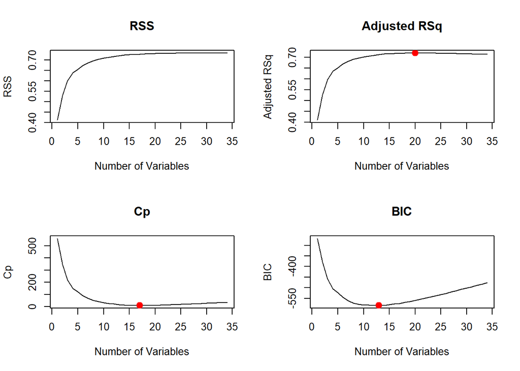

```r
par(mfrow = c(2,2))
plot(rsq, xlab = "Number of Variables", ylab = "RSS", main = "RSS", type = "l")
plot(adjr2, xlab = "Number of Variables", ylab = "Adjusted RSq", main = "Adjusted RSq", type = "l")
points(20,adjr2[20], col = "red", cex = 2, pch = 20)
plot(cp, xlab = "Number of Variables", ylab = "Cp",main = "Cp", type = "l")
points(17,cp[17], col = "red", cex = 2, pch = 20)
plot(bic, xlab = "Number of Variables", ylab = "BIC",main = "BIC",type = "l")
points(13,bic[13], col = "red", cex = 2, pch = 20)
```

검정 MSE에 대한 여러가지 추정 지표를 통해 확인 조정된 R^2는 20일 때 가장 크고, Cp는 17일 때 가장 낮고 BIC는 13일때 가장 낮고 그 뒤로 계속 커지는 것을 확인할 수 있었다.  
BIC가 가장 낮은 경우인 13개 일때, 세가지 지표가 최적치와 큰 차이가 나지 않기 때문에 변수가 13개 사용된 서브셋을 선택한다. (모델 선택이 감각적이지는 않는가?)  
(실제로는 11개인 모델을 사용했는데, 이는 HS_dropout 의 결측치가 너무 많았기 때문에 이를 제외하기 위함이었다. 실제 검정 지표상에서도 변수가 11일때, 큰 차이가 나지 않는다.)

```r
coef(lm_fit_full,11)
```

```
##           (Intercept)            Seg_racial          Middle_class
##          -0.095271631          -0.087352899           0.198905014
##        Local_tax_rate         Progressivity Student_teacher_ratio
##           0.774594032           0.006789830           0.002030449
##         Manufacturing          Migration_in             Religious
##          -0.195624739          -0.596408807           0.043465762
##         Violent_crime              Divorced               Married
##          -4.661417371          -0.395626516           0.175141185
```

위와 같은 변수들이 선택 되었다. 다음은 이 변수들 만을 가지고 다시 다중회귀분석을 한다.

#### 5-2 선택된 변수로 다중회귀분석.

```r
index = attr(coef(lm_fit_full,11), "names")[2:12]
index[12] <- "Mobility"
Raw_final = Raw_unvif[,index]
lm_final = lm(Mobility ~ ., data = Raw_final)
summary(lm_final)
```

```
##
## Call:
## lm(formula = Mobility ~ ., data = Raw_final)
##
## Residuals:
##       Min        1Q    Median        3Q       Max
## -0.089012 -0.016194 -0.002749  0.011807  0.159448
##
## Coefficients:
##                         Estimate Std. Error t value Pr(>|t|)
## (Intercept)           -0.0916108  0.0221646  -4.133 4.05e-05 ***
## Seg_racial            -0.0796957  0.0121636  -6.552 1.17e-10 ***
## Middle_class           0.1872143  0.0173531  10.789  < 2e-16 ***
## Local_tax_rate         0.5803042  0.1320612   4.394 1.30e-05 ***
## Progressivity          0.0045241  0.0007914   5.716 1.67e-08 ***
## Student_teacher_ratio  0.0018623  0.0006187   3.010  0.00272 **
## Manufacturing         -0.2054138  0.0150871 -13.615  < 2e-16 ***
## Migration_in          -0.5256558  0.1334944  -3.938 9.13e-05 ***
## Religious              0.0414663  0.0090454   4.584 5.48e-06 ***
## Violent_crime         -3.3029301  0.8234461  -4.011 6.76e-05 ***
## Divorced              -0.4796316  0.0799551  -5.999 3.33e-09 ***
## Married                0.2049010  0.0310177   6.606 8.33e-11 ***
## ---
## Signif. codes:  0 '***' 0.001 '**' 0.01 '*' 0.05 '.' 0.1 ' ' 1
##
## Residual standard error: 0.02812 on 638 degrees of freedom
##   (91 observations deleted due to missingness)
## Multiple R-squared:  0.6715, Adjusted R-squared:  0.6659
## F-statistic: 118.6 on 11 and 638 DF,  p-value: < 2.2e-16
```

```r
ta = tidy(lm_final)

kable(ta, caption = "coef table final multiple regression")
```

coef table final multiple regression

| term | estimate | std.error | statistic | p.value |
| --- | --- | --- | --- | --- |
| (Intercept) | -0.0916108 | 0.0221646 | -4.133206 | 0.0000405 |
| Seg_racial | -0.0796957 | 0.0121636 | -6.551998 | 0.0000000 |
| Middle_class | 0.1872143 | 0.0173531 | 10.788547 | 0.0000000 |
| Local_tax_rate | 0.5803042 | 0.1320612 | 4.394206 | 0.0000130 |
| Progressivity | 0.0045241 | 0.0007914 | 5.716414 | 0.0000000 |
| Student_teacher_ratio | 0.0018623 | 0.0006187 | 3.009778 | 0.0027176 |
| Manufacturing | -0.2054138 | 0.0150871 | -13.615186 | 0.0000000 |
| Migration_in | -0.5256558 | 0.1334944 | -3.937662 | 0.0000913 |
| Religious | 0.0414663 | 0.0090454 | 4.584239 | 0.0000055 |
| Violent_crime | -3.3029301 | 0.8234461 | -4.011107 | 0.0000676 |
| Divorced | -0.4796316 | 0.0799551 | -5.998762 | 0.0000000 |
| Married | 0.2049010 | 0.0310177 | 6.605948 | 0.0000000 |

### 6. 예측된 값을 지도상에 표현하고 실제 값과 비교.

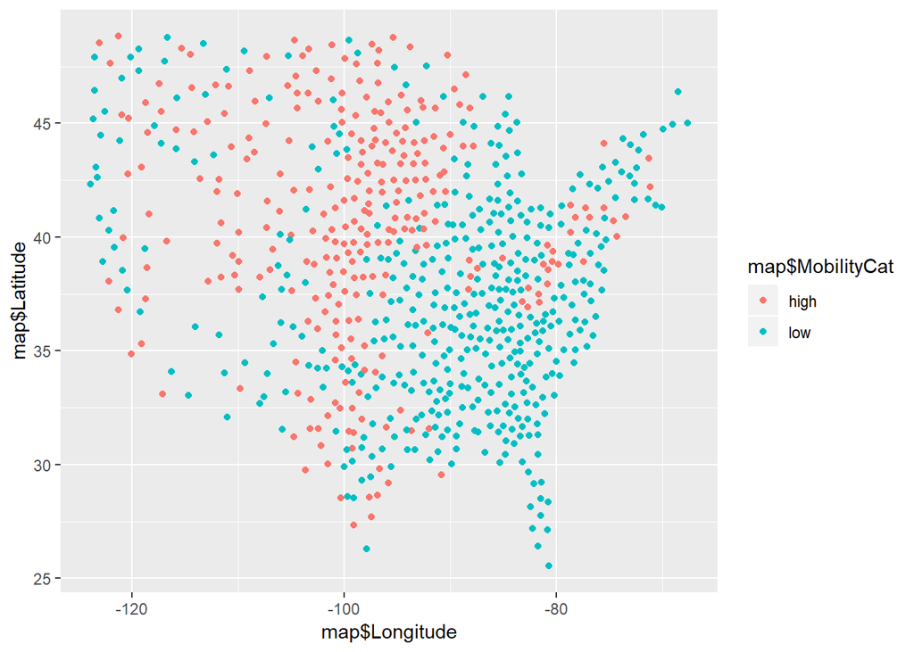

```r
# 실제 지도
map <- Raw %>% filter(!is.na(Raw$Mobility))
map$MobilityCat <- ifelse(map$Mobility > 0.1, "high","low")
map <- map %>% filter(Longitude > -145, Latitude < 50)
ggplot(data = map, aes(x = map$Longitude, y = map$Latitude, col = map$MobilityCat)) +
    geom_point()
```

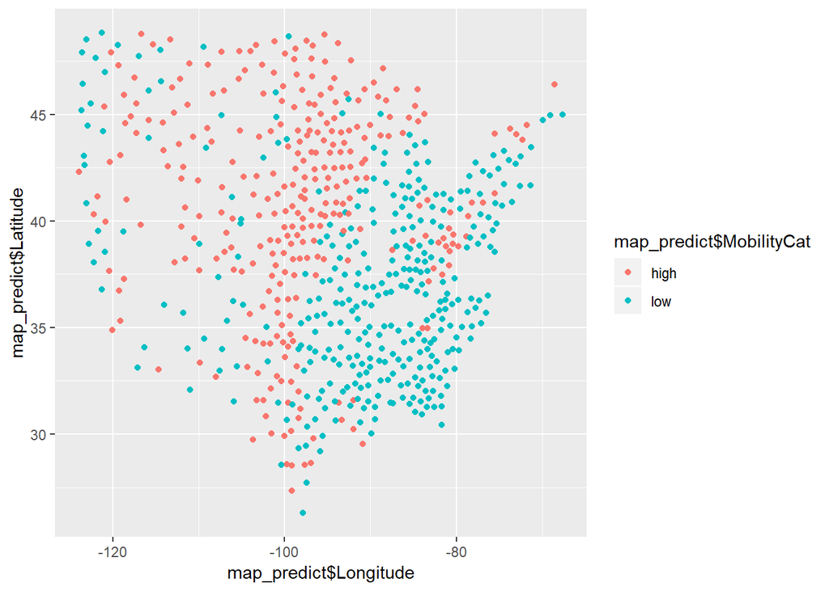

```r
# 예측 지도
temp = Raw_final
temp$Longitude  <- Raw$Longitude
temp$Latitude  <- Raw$Latitude
temp$Name <- Raw$Name

map_predict <- na.omit(temp)
yhat <- predict(lm_final)
map_predict$predicted_Mobility <- yhat
map_predict$MobilityCat <- ifelse(map_predict$predicted_Mobility > 0.1, "high","low")
map_predict <-map_predict %>% filter(Longitude > -145, Latitude < 50)
ggplot(data = map_predict, aes(x = map_predict$Longitude, y = map_predict$Latitude, col = map_predict$MobilityCat)) +
    geom_point()
```

누락된 값이 있어서 모든 관측치에 대한 예측치가 찍히지는 않았다.  
하지만, 찍힌 점들에 한해 실제값과 예측값을 비교해보면 유사한 패턴이 보인다.

### 7. 예측구간과 신뢰구간

#### a. Pittsburgh의 Mobility의 실제값과 예측값.

```r
temp = Raw %>% filter(Name == "Pittsburgh")
temp$Mobility
```

```
## [1] 0.09514869
```

```r
temp <- map_predict %>% filter(Name == "Pittsburgh")
temp$predicted_Mobility
```

```
## [1] 0.09422633
```

실제값은 0.09514869이고 예측값은 0.09422633으로 거의 유사하다.

#### b. 폭력범죄율 변화에 따른 Mobility의 변화.

```r
Pittsburgh <- map_predict %>% filter(Name == "Pittsburgh")
Pittsburgh$Violent_crime
```

```
## [1] 0.002
```

```r
coef(lm_final)[10]
```

```
## Violent_crime
##      -3.30293
```

만일 범죄율이 두배 증가해서 0.004가되면, 범죄율이 0.002 증가한다. 따라서 Mobility가 -0.0066(회귀계수가 -3.3이므로) 정도 감소한다.  
반면 범죄율이 절반이 돼서 0.001이 되면, 범죄율이 0.001 감소한다. 따라서 Mobility는 0.0033 만큼 증가한다.

#### c. 신뢰구간

```r
predict(lm_final, newdata = Pittsburgh, interval = "confidence" )
```

```
##          fit        lwr       upr
## 1 0.09422633 0.08763612 0.1008165
```

#### d. 예측구간

```r
predict(lm_final, newdata = Pittsburgh, interval = "prediction" )
```

```
##          fit        lwr       upr
## 1 0.09422633 0.03862444 0.1498282
```

신뢰구간은 반응 변수의 평균의 불확실성을 수량화하는데 사용한다. 이는 [0.08763612 0.1008165]구간 중 95퍼센트는 피츠버그와 같은 조건을 가진 관측치들의 실제 평균을 포함한다.  
예측구간은 특정 반응 변수의 불확실성을 수량하는데 사용한다. 이는 [0.03862444 0.1498282] 구간 중 95퍼센트는 이 도시에 대한 실제값을 포함한다.

### 8. After making proper allowances

#### a. 잔차지도

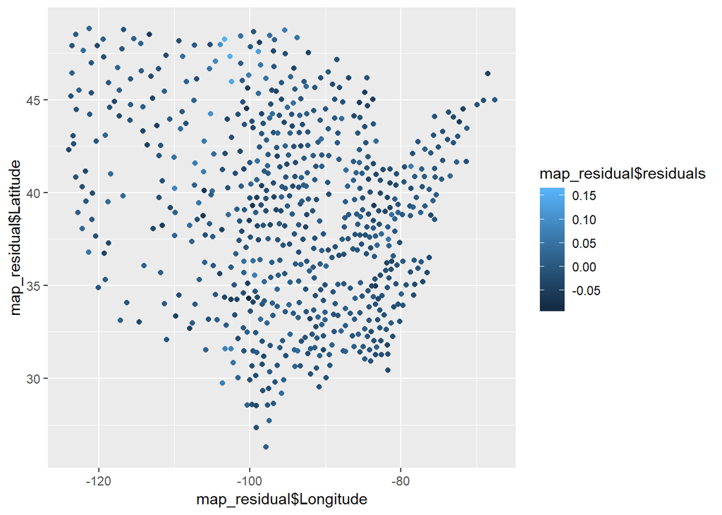

```r
lm_final = lm(Mobility ~ ., data = Raw_final)


# 잔차지도
temp = Raw_final
temp$Longitude  <- Raw$Longitude
temp$Latitude  <- Raw$Latitude
temp$Name <- Raw$Name


map_residual<- na.omit(temp)
map_residual$residuals <- lm_final$residuals
map_residual <-map_residual %>% filter(Longitude > -145, Latitude < 50)
ggplot(data = map_residual, aes(x = map_residual$Longitude, y = map_residual$Latitude, col = map_residual$residuals)) +
    geom_point()
```

잔차은 값들이 중부지역중에서도 북부에 몰려있는 것을 확인할 수 있다.

#### b. 상위 5위와 하위 5위

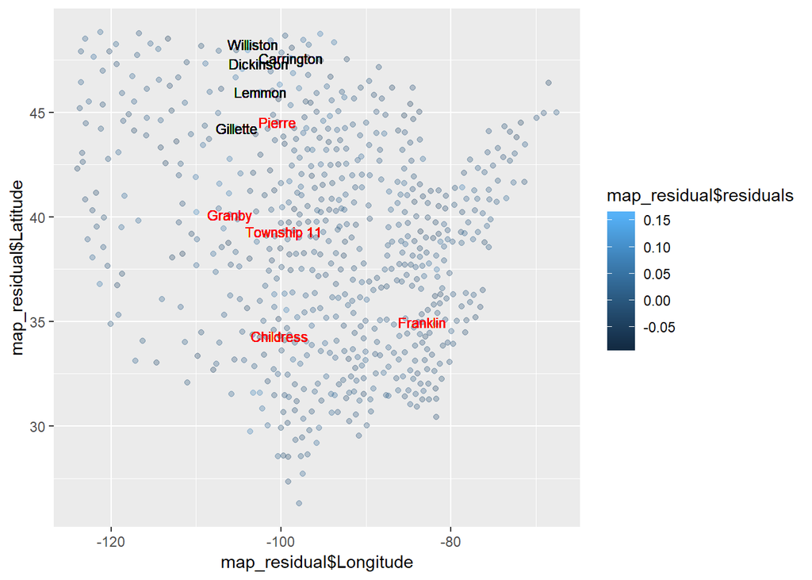

```r
low <- map_residual %>% dplyr::select(Name, residuals, Longitude, Latitude) %>%
    arrange(residuals) %>% head(5)

high <- map_residual %>% dplyr::select(Name, residuals, Longitude, Latitude) %>%
    arrange(desc(residuals)) %>% head(5)

map_hl = rbind(low,high)
map_hl$cat = ifelse(map_hl$residuals < 0, 0, 1)

plot1 <- ggplot(data = map_residual, aes(x = map_residual$Longitude, y = map_residual$Latitude, col = map_residual$residuals)) +
    geom_point(alpha = 0.3, fill = "white")

plot2 <- plot1 +
geom_text(x=high$Longitude[1], y = high$Latitude[1], label = high$Name[1], col = "black",size = 3) +
geom_text(x=high$Longitude[2], y = high$Latitude[2], label = high$Name[2], col = "black",size = 3) +
geom_text(x=high$Longitude[3], y = high$Latitude[3], label = high$Name[3], col = "black",size = 3) +
geom_text(x=high$Longitude[4], y = high$Latitude[4], label = high$Name[4], col = "black",size = 3) +
geom_text(x=high$Longitude[5], y = high$Latitude[5], label = high$Name[5], col = "black",size = 3) + geom_text(x=low$Longitude[1], y = low$Latitude[1], label = low$Name[1], col = "red",size = 3) +
geom_text(x=low$Longitude[2], y = low$Latitude[2], label = low$Name[2], col = "red",size = 3) +
geom_text(x=low$Longitude[3], y = low$Latitude[3], label = low$Name[3], col = "red",size = 3) +
geom_text(x=low$Longitude[4], y = low$Latitude[4], label = low$Name[4], col = "red",size = 3) +
geom_text(x=low$Longitude[5], y = low$Latitude[5], label = low$Name[5], col = "red",size = 3)



print(plot2)
```

상위 관측치는 검은색으로 표시했고, 하위 관측치는 빨간색으로 표시했다. 상위와 하위 관측치는 모두 중부에 몰려있고 그 중에서도 상위관측치는 중부중에서도 상위에 위치하고 하위 관측치는 아래에 분포한다.

### 9. 예측값과 실제값 비교.

#### a. y-yhat

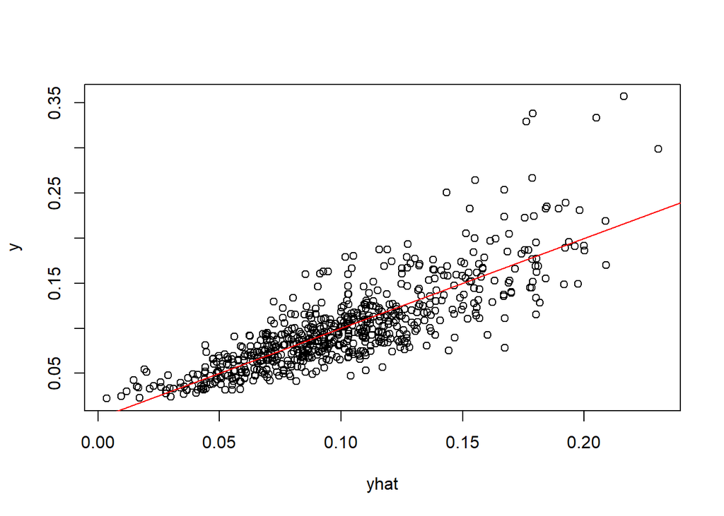

```r
index = as.numeric(unique(attr(yhat, "names")))
y = Raw$Mobility[index ]
plot(y~yhat)
abline(a = 0, b = 1, col = "red")
```

y와 yhat이 그래프 상에서 기울기가 1인 직선에 가까울 수록 좋은 결과로 볼 수 있다.  
경제적 이동성이 작을 경우, 예측을 잘하지만 경제적 이동성이 커질 수록 예측의 정확도가 떨어진다.

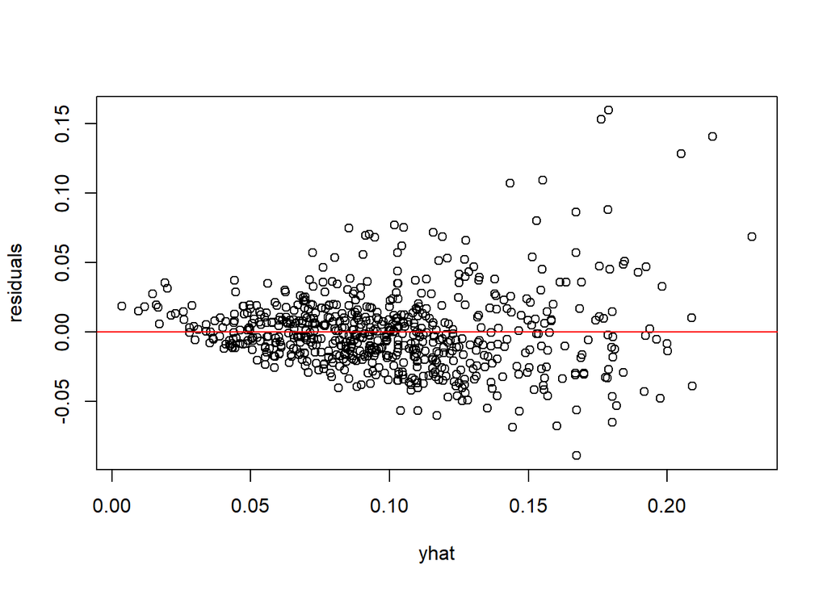

```r
residuals = y - yhat
plot(residuals~yhat)
abline(h=0, col = "red")
```

잔차와 예측치의 그래프이다. 잔차가 0일 수록 예측이 정확하다. 잔차도에서 뚜렷한 패턴(0에 대칭)이기 때문에 오차항이 서로 상관이 없다는 가정은 적합하다.  
그러나 상기에 기술한 바와 같이, 경제적 이동성이 커질 수록 오차의 분산이 커지는 경향이 확인된다. 이는 선형모델의 등분산성 가정과 맞지 않다. 따라서 y의 log 변환 등 유연성 증가를 통해 모델의 정확성을 향상시킬 수 있을 것이다.

### 10. cross-validation, bootstrap, smoothing

#### a. middle class 를 이용한 단위회귀분석

```r
attach(Raw)
lm_mid = lm(Mobility~Middle_class)
summary(lm_mid)
```

```
##
## Call:
## lm(formula = Mobility ~ Middle_class)
##
## Residuals:
##       Min        1Q    Median        3Q       Max
## -0.077571 -0.026298 -0.009883  0.017227  0.215977
##
## Coefficients:
##              Estimate Std. Error t value Pr(>|t|)
## (Intercept)  -0.09698    0.01040  -9.328   <2e-16 ***
## Middle_class  0.35385    0.01871  18.908   <2e-16 ***
## ---
## Signif. codes:  0 '***' 0.001 '**' 0.01 '*' 0.05 '.' 0.1 ' ' 1
##
## Residual standard error: 0.03916 on 707 degrees of freedom
##   (32 observations deleted due to missingness)
## Multiple R-squared:  0.3358, Adjusted R-squared:  0.3349
## F-statistic: 357.5 on 1 and 707 DF,  p-value: < 2.2e-16
```

```r
pred_mid <- predict(lm_mid , Raw , interval = "prediction")
str(pred_mid)
```

```
##  num [1:741, 1:3] 0.0969 0.0934 0.0683 0.0814 0.08 ...
##  - attr(*, "dimnames")=List of 2
##   ..$ : chr [1:741] "1" "2" "3" "4" ...
##   ..$ : chr [1:3] "fit" "lwr" "upr"
```

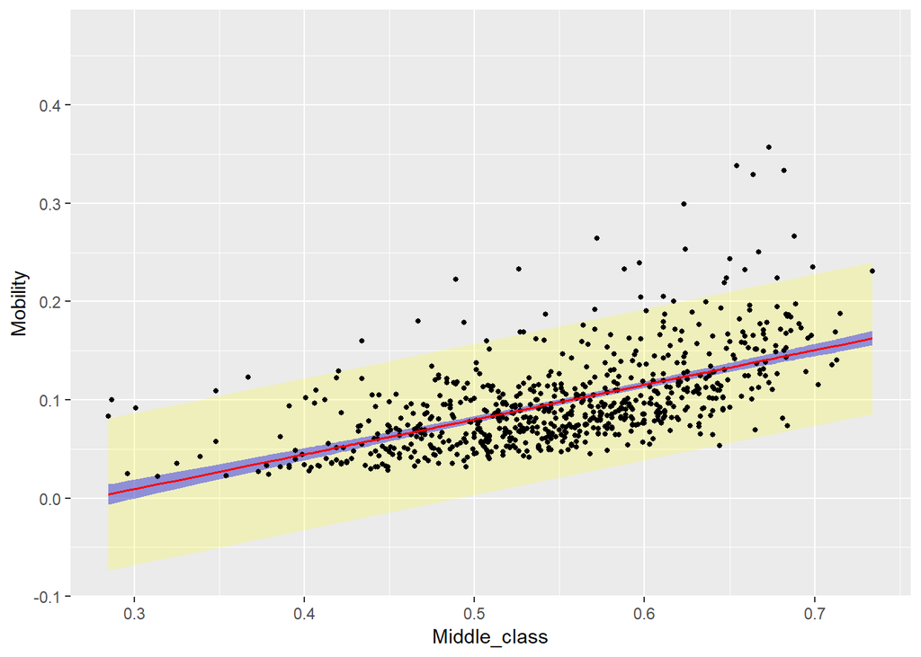

```r
detach(Raw)


colnames(pred_mid) <- c("fit_pred", "lwr_pred", "upr_pred")
Raw_10 <- cbind(Raw, pred_mid)

conf_mid <- predict(lm_mid ,Raw, interval = "confidence")
colnames(conf_mid) <- c("fit_conf", "lwr_conf", "upr_conf")
Raw_10 <- cbind(Raw_10, conf_mid)

ggplot(Raw_10 , aes(x = Middle_class)) +
  geom_ribbon(aes(ymin = lwr_pred, ymax = upr_pred),
              fill = "yellow", alpha = 0.2) +
  geom_ribbon(aes(ymin = lwr_conf, ymax = upr_conf),
              fill = "blue", alpha = 0.4) +
  geom_point(aes(y = Mobility), colour = "black", size = 1) +
  geom_line(aes(y = fit_pred), colour = "red", size = 0.7)
```

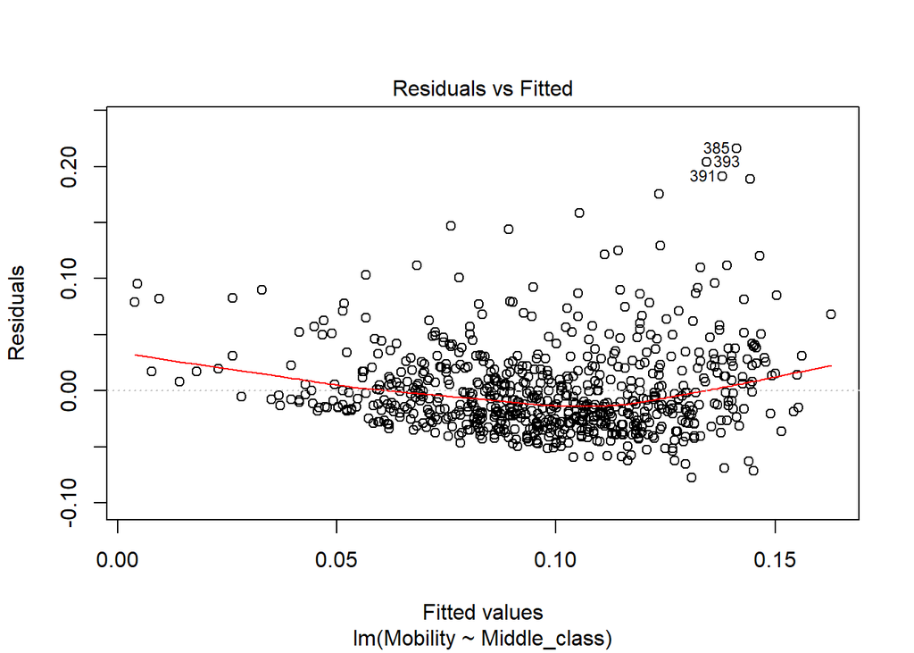

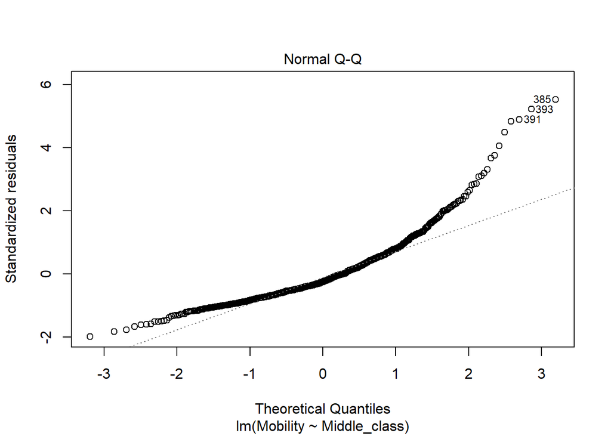

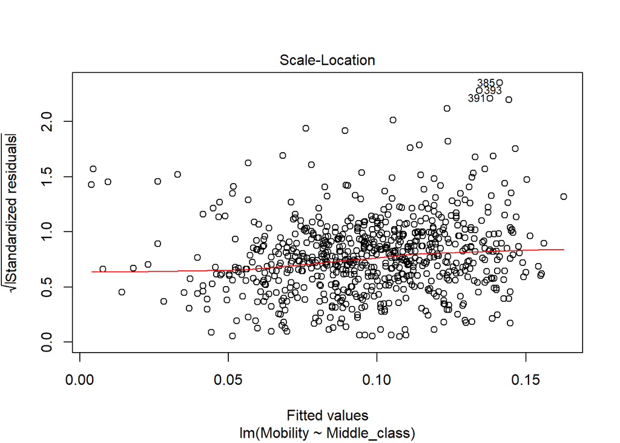

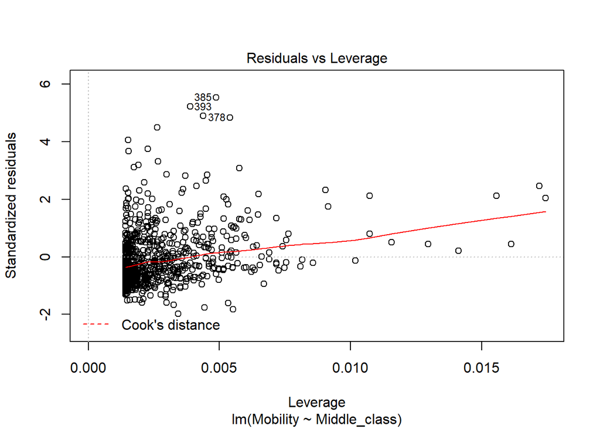

```r
plot(lm_mid)
```

qqplot을 확인해보면, noise의 분포가 정규분포가 아님을 확인할 수 있다. 데이터의 양 끝으로 갈수록 가정이 점차 깨지는데, 이는 회귀 그래프 상에서 신뢰구간이 뒤로 갈수록 넓어지는 것과 관련된다.  
또한 잔차도 상에서 잔차의 패턴이 확인되는데, 이차함수 꼴을 하고 있다. 따라서 설명변수의 2차항을 추가해 유연성을 증가시키면 편향이 줄어들어 더 좋은 모델이 될 것이다.

#### b. resampling.

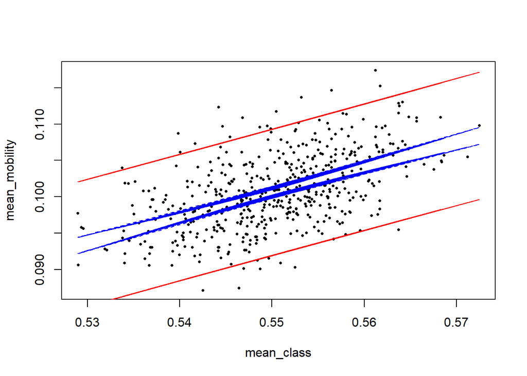

```r
library(data.table)
## mean
dat_boot2 <- list()

for(i in 1:500){
  dat_boot2[[i]] <- Raw_final %>%
    sample_n(size = 100) %>%
    summarise(mean_mobility = mean(Mobility, na.rm = T), mean_class = mean(Middle_class, na.rm = T))
}

dat_boot2 = data.table::rbindlist(dat_boot2)
model2 = lm(mean_mobility ~ mean_class, data = dat_boot2)
pred_con2 = predict(model2, newdata = dat_boot2, interval = 'confidence')
pred_pre2 = predict(model2, newdata = dat_boot2, interval = 'prediction')

plot(mean_mobility ~ mean_class, data = dat_boot2, pch = 16, cex = 0.5)
lines(dat_boot2$mean_class, pred_con2[,"lwr"], lty="dashed", col="blue")
lines(dat_boot2$mean_class, pred_con2[,"upr"], lty="dashed", col="blue")
lines(dat_boot2$mean_class, pred_pre2[,"lwr"], col="red")
lines(dat_boot2$mean_class, pred_pre2[,"upr"], col="red")
```

```r
par(mfrow = c(1,1))
```

#### c-1 함수 준비.

```r
resampler <- function(data) {
  n <- nrow(data)
  resample.rows <- sample(1:n,size=n,replace=TRUE)
  return(data[resample.rows,])
}

spline.estimator <- function(data,m=300) {
  fit <- smooth.spline(x=data[,1],y=data[,2], cv = TRUE)
  eval.grid <- seq(from=min(data[,1]),to=max(data[,1]),length.out=m)
  return(predict(fit,x=eval.grid)$y) # We only want the predicted values
}

spline.cis <- function(data,B,alpha=0.05,m=300) {
  spline.main <- spline.estimator(data,m=m)
  spline.boots <- replicate(B,spline.estimator(resampler(data),m=m))
  cis.lower <- 2*spline.main - apply(spline.boots,1,quantile,probs=1-alpha/2)
  cis.upper <- 2*spline.main - apply(spline.boots,1,quantile,probs=alpha/2)
  return(list(main.curve=spline.main,lower.ci=cis.lower,upper.ci=cis.upper,
              x=seq(from=min(data[,1]),to=max(data[,1]),length.out=m)))
}
```

#### c-2 스플라인 실행.

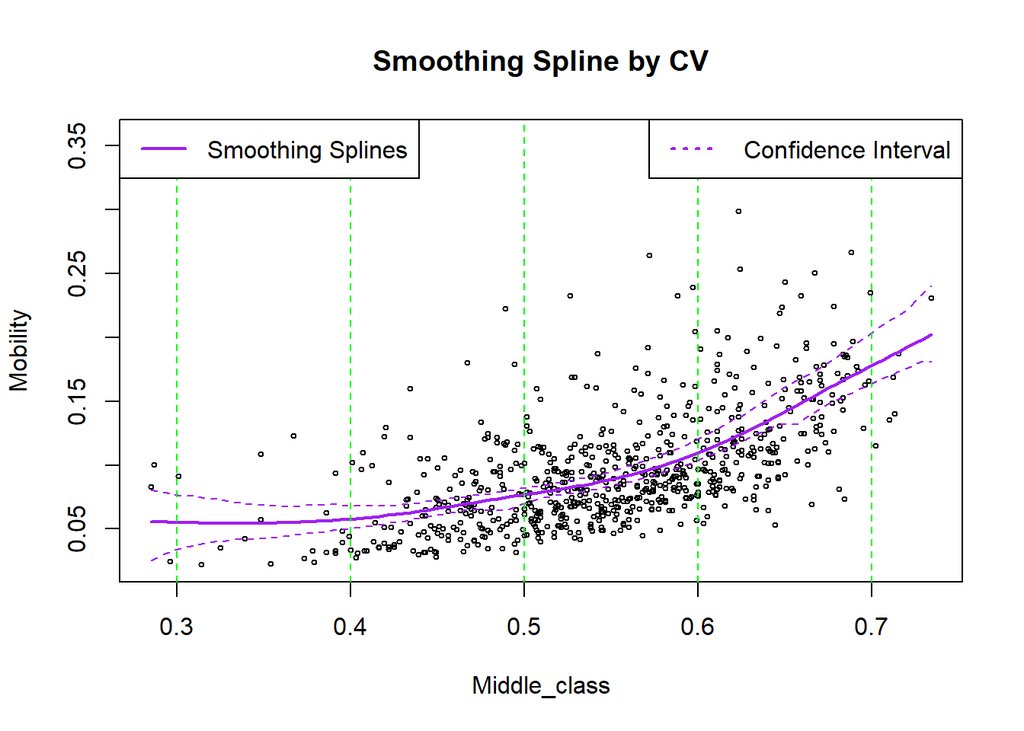

```r
par(mfrow = c(1,1))
library(splines)
library(bigsplines)
#data
par(mfrow = c(2,1))
attach(Raw_final)
a <- Middle_class[!is.na(Middle_class)]
b <- Mobility[!is.na(Middle_class)]
ab <- data.frame(cbind(a,b))
detach(Raw_final)
attach(Raw_final)
#run and plot
par(mfrow = c(1,1))
sp.cis <- spline.cis(ab, B=1000,alpha=0.05,m=100)
plot(ab[,1],ab[,2], cex = 0.5, main = "Smoothing Spline by CV",
     xlab = "Middle_class", ylab = "Mobility")
lines(x=sp.cis$x,y=sp.cis$main.curve, col = "purple", lwd=2)
lines(x=sp.cis$x,y=sp.cis$lower.ci, lty=2, col = "purple")
lines(x=sp.cis$x,y=sp.cis$upper.ci, lty=2, col = "purple")
abline(v=c(0.3,0.4,0.5,0.6,0.7),lty=2,col="green")
legend("topleft",("Smoothing Splines"),col="purple",lwd=2)
legend("topright",(" Confidence Interval"),col="purple",lwd=2,lty=3)
```

```r
detach(Raw_final)
```

스무딩을 한 결과 데이터에 더욱 잘 맞는데, 이는 앞서 확인했던 것 처럼 설명변수와 반응변수의 관계가 선형이 아니었기 때문이다.  
따라서 모델을 가정하지 않는 스플라인의 적합결과가 더욱 좋다.  
하지만, 끝에 있는 관측치의 경우, 개별 관측치의 분산 때문에 신뢰구간이 더욱 커진다.

#### d.

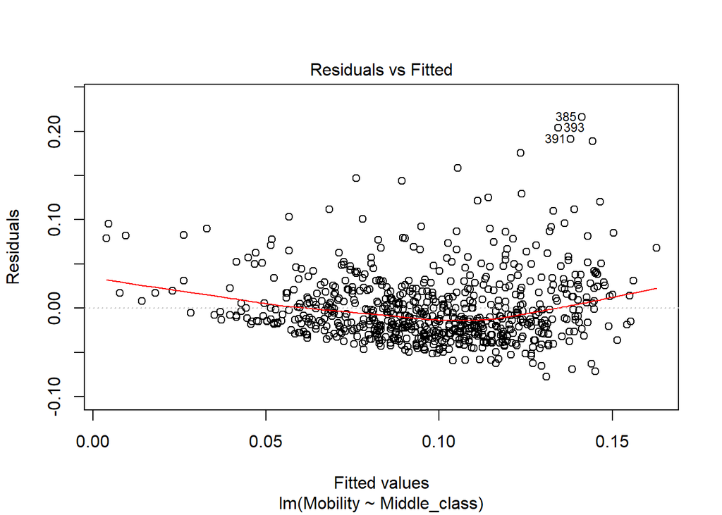

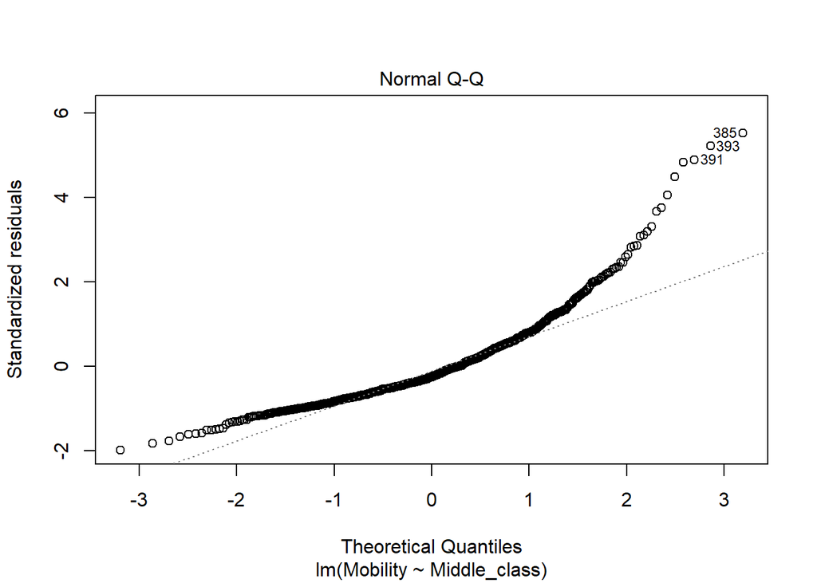

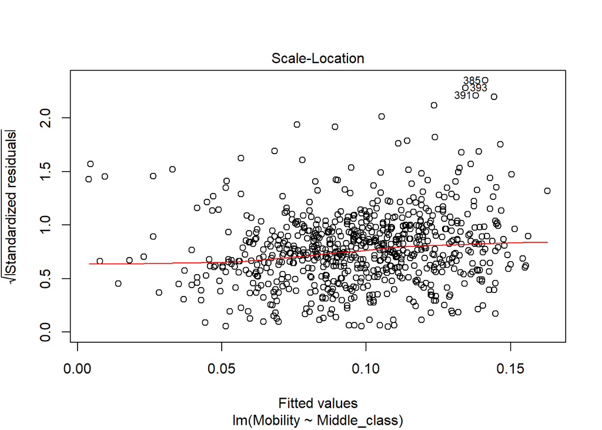

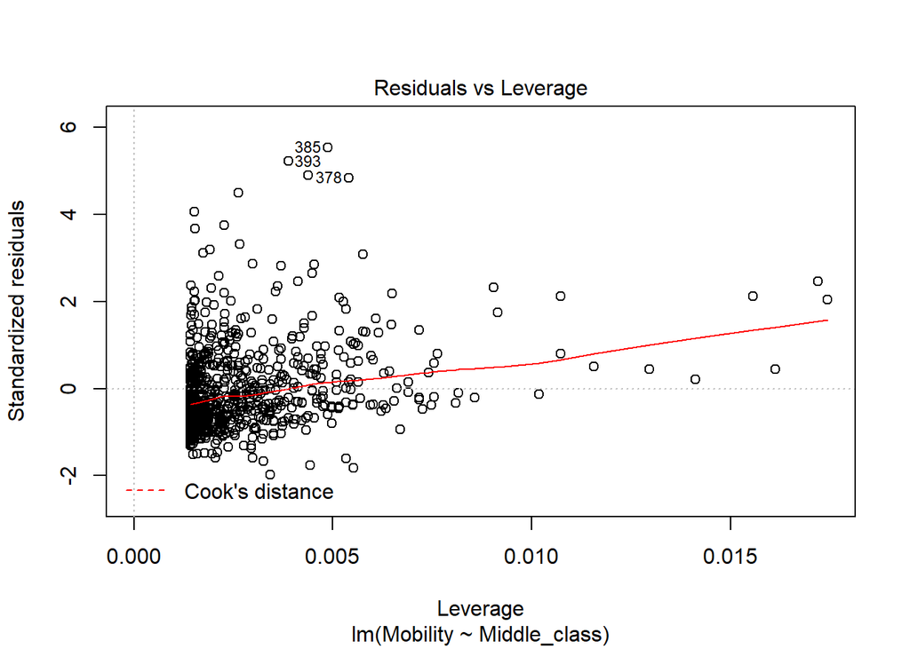

```r
plot(lm_mid)
```

```r
shapiro.test(resid(lm_mid))
```

```
##
##  Shapiro-Wilk normality test
##
## data:  resid(lm_mid)
## W = 0.87933, p-value < 2.2e-16
```

잔차도에서도 패턴이 확인되고, qqplot에서도 잔차의 정규성이 확인되지 않는다. 따라서 정규성과 선형성을 가정하는 선형모델은 부적합하고 스플라인 활용이 대안이 될 수 있다.  
정규성 검정하는 shapiro에서도 p-value가 낮기 때문에 귀무가설인 “데이터가 정규분포를 따른다.” 를 기각할 수 있고, 데이터가 정규성을 따르지 않은 것을 파악할 수 있다.